# Notes for MDCH07: Sampling

Saturday, March 20, 2021 @ 02:13 PM

### Modern Dive Chapter 7: Sampling

#### Introduction

In this chapter, we kick off the third portion of this book on statistical inference by learning about sampling. The concepts behind sampling form the basis of confidence intervals and hypothesis testing, which we’ll cover in Chapters 8 and 9. We will see that the tools that you learned in the data science portion of this book, in particular data visualization and data wrangling, will also play an important role in the development of your understanding. As mentioned before, the concepts throughout this text all build into a culmination allowing you to “tell your story with data.”

#### Chapter Link

Go to [Modern Dive Chapter 7: Sampling](https://moderndive.com/7-sampling.html).

### 7.1 Sampling bowl activity

#### 7.1.1 What proportion of this bowl’s balls are red?

#### 7.1.2 Using the shovel once

#### 7.1.3 Using the shovel 33 times

#### 7.1.4 What did we just do?

### 7.2 Virtual sampling

#### 7.2.1 Using the virtual shovel once

#### 7.2.2 Using the virtual shovel 33 times

#### 7.2.3 Using the virtual shovel 1000 times

#### 7.2.4 Using different shovels

### 7.3 Sampling framework

#### 7.3.1 Terminology and notation

#### 7.3.2 Statistical definitions

#### 7.3.3 The moral of the story

### 7.4 Case study: Polls

### 7.5 Conclusion

#### 7.5.1 Sampling scenarios

#### 7.5.2 Central Limit Theorem

#### 7.5.3 Additional resources

#### 7.5.4 What’s to come?

### Learning Check

**Learning Check Questions**

**(LC7.1)** Why was it important to mix the bowl before we sampled the balls?

**(LC7.2)** Why is it that our 33 groups of friends did not all have the same numbers of balls that were red out of 50, and hence different proportions red?

**(LC7.3)** Why couldn’t we study the effects of sampling variation when we used the virtual shovel only once? Why did we need to take more than one virtual sample (in our case 33 virtual samples)?

**(LC7.4)** Why did we not take 1000 “tactile” samples of 50 balls by hand?

**(LC7.7)** What summary statistic did we use to quantify how much the 1000 proportions red varied?

- A. The interquartile range
- B. The standard deviation
- C. The range: the largest value minus the smallest.

**(LC7.8)** In the case of our bowl activity, what is the *population parameter*? Do we know its value?

**(LC7.9)** What would performing a census in our bowl activity correspond to? Why did we not perform a census?

**(LC7.10)** What purpose do *point estimates* serve in general? What is the name of the point estimate specific to our bowl activity? What is its mathematical notation?

**(LC7.11)** How did we ensure that our tactile samples using the shovel were random?

**(LC7.12)** Why is it important that sampling be done *at random*?

**(LC7.13)** What are we *inferring* about the bowl based on the samples using the shovel?

For the following four *Learning Checks*, let the *estimate* be the sample proportion $\hat{p}$ : the proportion of a shovel’s balls that were red. It estimates the population proportion $p$ : the proportion of the bowl’s balls that were red.

**(LC7.17)** What is the difference between an *accurate* and a *precise* estimate?

**(LC7.18)** How do we ensure that an estimate is accurate? How do we ensure that an estimate is precise?

**(LC7.19)** In a real-life situation, we would not take 1000 different samples to infer about a population, but rather only one. Then, what was the purpose of our exercises where we took 1000 different samples?

**(LC7.20)** Figure 7.16 with the targets shows four combinations of “accurate versus precise” estimates. Draw four corresponding sampling distributions of the sample proportion $\hat{p}$, like the one in the leftmost plot in Figure 7.15.

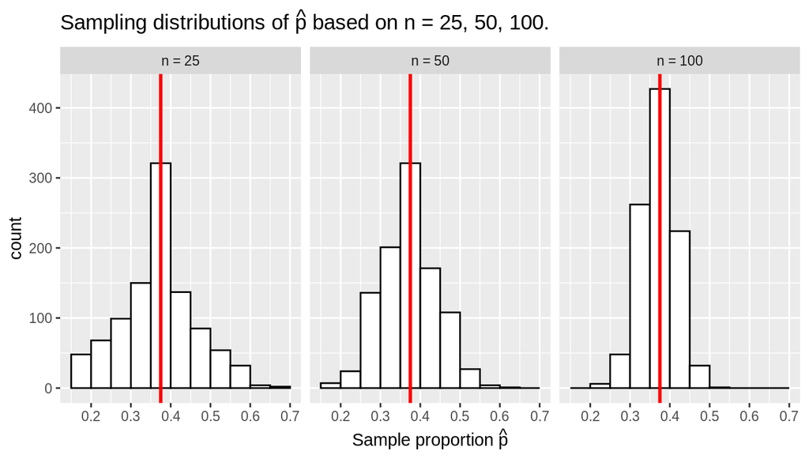

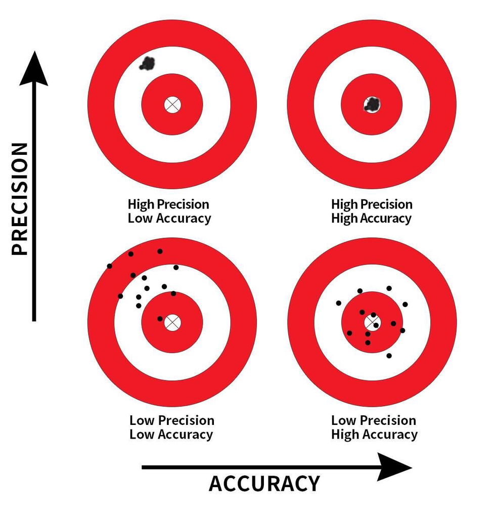

FIGURE 7.16: Comparing accuracy and precision.

Comment on the representativeness of the following *sampling methodologies*:

**(LC7.21)** The Royal Air Force wants to study how resistant all their airplanes are to bullets. They study the bullet holes on all the airplanes on the tarmac after an air battle against the Luftwaffe (German Air Force).

**(LC7.22)** Imagine it is 1993, a time when almost all households had landlines. You want to know the average number of people in each household in your city. You randomly pick out 500 phone numbers from the phone book and conduct a phone survey.

**(LC7.23)** You want to know the prevalence of illegal downloading of TV shows among students at a local college. You get the emails of 100 randomly chosen students and ask them, “How many times did you download a pirated TV show last week?”.

**(LC7.24)** A local college administrator wants to know the average income of all graduates in the last 10 years. So they get the records of five randomly chosen graduates, contact them, and obtain their answers.